# Lab #5

Kerstin Swanson

4/11/2021

## Data Background

```r
acc <- read.csv("https://raw.githubusercontent.com/xdaiISU/ds202materials/master/hwlabs/fars2017/accident.csv", stringsAsFactors = FALSE)
pers <- read.csv("https://raw.githubusercontent.com/xdaiISU/ds202materials/master/hwlabs/fars2017/person.csv", stringsAsFactors = FALSE)
```

```r
library(tidyverse)
```

```r
library(ggplot2)
library(maps)
```

## Questions

1. Are there some days of the week where more accidents happen than the others (see FARS manual, use variable DAY_WEEK)?

```r
acc %>%
  group_by(DAY_WEEK) %>%
  summarise(count = n()) %>%
  arrange(desc(count))
```

```
## # A tibble: 7 x 2
##   DAY_WEEK count
##      <int> <int>
## 1        7  5873
## 2        1  5360
## 3        6  5358
## 4        5  4621
## 5        2  4374
## 6        3  4347
## 7        4  4314
```

Yes, there are certain days of the week where accidents happen more than others. Saturday, Sunday, and Friday have more accidents than other days, which makes sense because those are weekend days.

2. Create a data frame containing the persons who are fatally hurt in the accidents (look up variable INJ_SEV)

```r
fatal <- pers %>%
  filter(INJ_SEV == 4)
```

3. Create a data frame containing the most dangerous vehicle make in each state. The number of persons fatally hit in the vehicle make is used to assess the (non-)safety of a make. Make sure to handle the missing values appropriately. (look up variable MAKE)

```r
car_fatal <- fatal %>%
  filter(complete.cases(fatal)) %>%
  group_by(STATE, MAKE) %>%
  summarise(count=n()) %>%
  arrange(desc(count)) %>%
  slice(1)
```

4. Create a map, and label each state with the most dangerous vehicle. Discuss the definition of the most dangerous vehicle, and what you find from the map. (Hint: Read the description for the STATE and COUNTY columns in the FARS manual. The state & county codes are Geographic Locator Codes (GLCs) from the General Services Administration’s (GSA) publication. Use readxl::read_xlsx to read in the GLCs.)

```r
glc<- readxl::read_xlsx("FRPP_GLC_-_United_StATESaPRIL62021.xlsx")
```

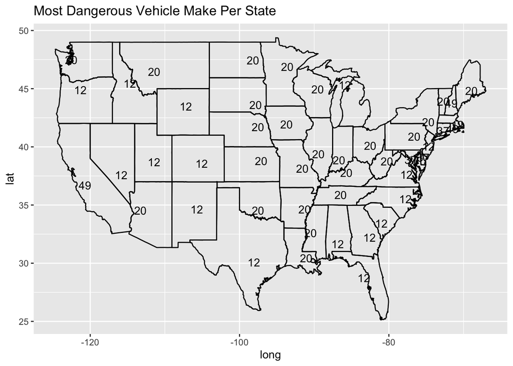

```r
glc$`State Code`<- as.numeric(glc$`State Code`)
glc2 <- glc %>%
  select(`State Name`, `State Code`)
car_state <- left_join(car_fatal, glc2, by=c("STATE"="State Code")) %>%
  unique()
car_state$`State Name`<- tolower(car_state$`State Name`)
states <- map_data('state')
carName <- states %>% group_by(region) %>% left_join(car_state, by = c("region"="State Name")) %>% summarize(long=mean(long), lat=mean(lat), make = MAKE) %>% unique()
states %>% ggplot(aes(x = long, y = lat)) +
  geom_path(aes(group = group))+ geom_text(aes(label=make), color='black', data=carName) + labs(title="Most Dangerous Vehicle Make Per State")
```

To qualify a car being the most dangerous in each state, I created a dataset that included only accidents that resulted in fatalities. Then, I grouped that data by state and make of car, and found the count of fatalities for each make/state combination. I then created a new dataframe that only included the make with the highest count of fatalities for each state. There are four different makes shown on this map: 12, 20, 37, and 49. Make 12 represents Ford, Make 20 represents Chevy, Make 37 represents Honda, and Make 49 represents Toyota. We can see the majority of the most dangerous vehicles are either a Ford or Chevy, which makes sense because these are highly purchased American-made cars.

5. Join the accident and person table (work out which variable(s) to use)

```r
acc_pers <- inner_join(pers, acc, by=c("STATE","ST_CASE"))
```

6. Tally the number of accidents by day of the week (DAY_WEEK), hour of the day (HOUR) and gender (SEX). Visualize the results and explain what you find.

```r
library(gridExtra)
```

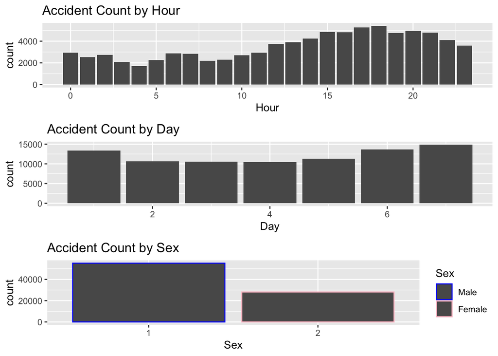

```r
p1<-  acc_pers %>%
  group_by(HOUR.x) %>%
  summarise(count=n()) %>%
  slice(1:24) %>%
  ggplot(aes(x=HOUR.x, weight=count)) + geom_bar()  + labs(title="Accident Count by Hour", x="Hour")

p2<-  acc_pers %>%
  group_by(DAY_WEEK) %>%
  summarise(count=n()) %>%
  slice(1:7) %>%
  ggplot(aes(x=DAY_WEEK, weight=count)) + geom_bar() + labs(title="Accident Count by Day", x="Day")

p3 <- acc_pers %>%
  group_by(SEX) %>%
  summarise(count=n()) %>%
  slice(1:2) %>%
  ggplot(aes(x=as.factor(SEX), weight=count, color=as.factor(SEX))) + geom_bar()+ labs(title="Accident Count by Sex", x="Sex", color="Sex") + scale_color_manual(labels = c("Male", "Female"), values=c("blue","pink"))

grid.arrange(p1, p2, p3,  nrow = 3)
```

First, I removed all records of hour, sex, or day unknown/not reported. We can see that the days with the most accidents occur on weekends (days 1, 6, 7), as we saw earlier. We can also see that the more accidents occur between 3 pm to 8 pm than other hours, which also makes sense because that is when the school/ work commute to home begins. Also, we can see that the majority of accidents involve men.

7. Now plot a choropleth map of the number of deaths on a county level. Also explain what you find.

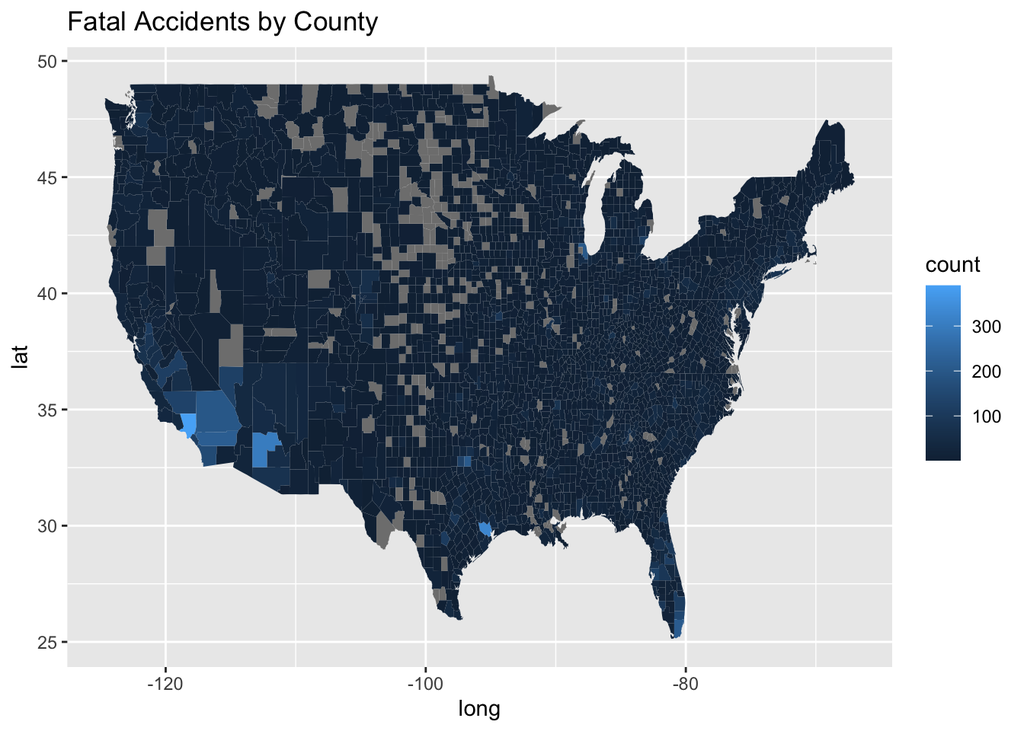

```r
county <- map_data('county')
glc3 <- glc %>%
  select(`State Name`, `County Name`, `County Code`) %>%
  mutate(`State Name` = tolower(`State Name`), `County Name` = tolower(`County Name`))
county_glc3 <- left_join(county, glc3, by= c("region"="State Name", "subregion"="County Name"))

county_fatal <- fatal %>%
  filter(complete.cases(fatal)) %>%
  group_by(STATE, COUNTY) %>%
  summarise(count=n()) %>%
  unique()
df <- left_join(county_fatal, glc2, by=c("STATE"="State Code")) %>% mutate(`State Name` = tolower(`State Name`)) %>% unique()

county_glc3$`County Code` <- as.numeric(county_glc3$`County Code`)
df2 <- left_join(county_glc3, df, by=c("region"= "State Name", "County Code"="COUNTY"))

ggplot(df2, aes(x=long, y=lat)) + geom_polygon(aes(group=group, fill=count)) + labs(title="Fatal Accidents by County")
```

From the choropleth maps shown above, we can see that some counties in the Western US seem to have the highest fatal accidents (especially California), with a few dangerous counties in Texas and Florida. This map makes sense, because more highly populated/trafficked areas seem to have higher fatalities (such as the coasts), and places in the Midwest have lower amounts of fatal accidents.

8. Is summer or winter more dangerous? Does this depend on states? Explore and explain.

```r
fatal$season <- ifelse(fatal$MONTH %in% c(4:9), "Summer", "Winter")
fatal2<- fatal %>%
  select(STATE, MONTH, season) %>%
  group_by(STATE, season) %>%
  summarise(count = n())
fatal_state <- left_join(fatal2, glc2, by=c("STATE"="State Code")) %>%  unique()
fatal_state$`State Name` <- tolower(fatal_state$`State Name`)

fatal_states <- left_join(states, fatal_state, by=c("region" = "State Name"))

fatal_states %>%
  group_by(season) %>%
  summarise(count = sum(count))
```

```
## # A tibble: 2 x 2
##   season   count
## * <chr>    <int>
## 1 Summer 9210103
## 2 Winter 8794502
```

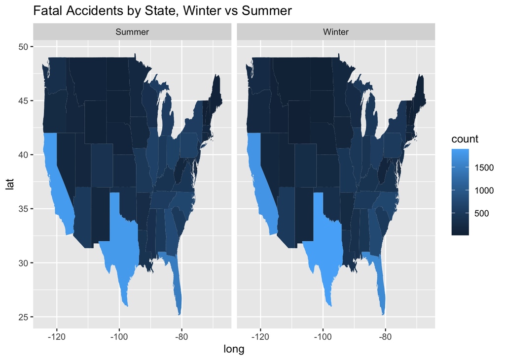

```r
ggplot(fatal_states, aes(x=long, y=lat)) + geom_polygon(aes(group=group, fill=count)) + facet_wrap(~season) + labs(title="Fatal Accidents by State, Winter vs Summer")
```